# 3-phase rectifier

The three-phase diode rectifier given below is connected to a three-phase ac voltage source through inductor $L=5\,$mH.

1. Plot the DC voltage ($V_{pm}$).
2. What is the average value of $V_{pm}$?
3. What is the power delivered to the current source?
4. What is the duration for which a diode conducts in one fundamental cycle of the input voltage?
5. Which are the dominant harmonics in the ac line current?

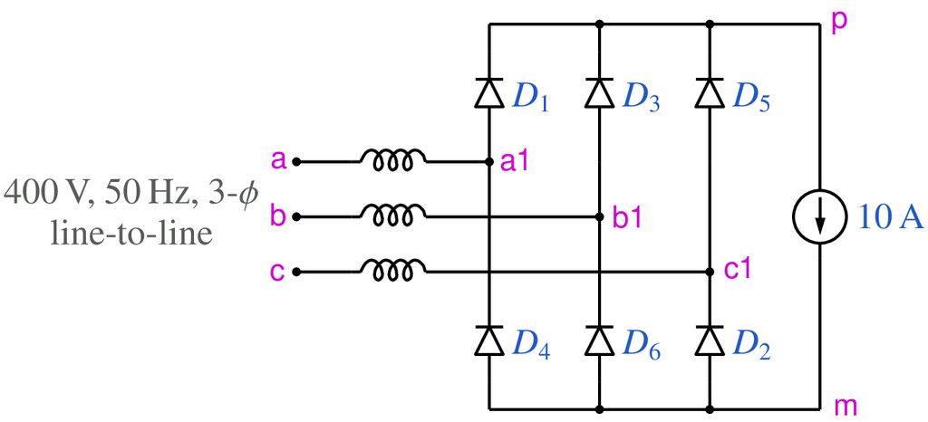

```python
from IPython.display import Image
Image(filename =r'rectifier_3ph_8_fig_1.png', width=450)
```

```python
# run this cell to view the circuit file.
%pycat rectifier_3ph_8_orig.in
```

We now replace the strings such as `\$L` with the values of our choice by running the python script given below. It takes an existing circuit file `rectifier_3ph_8_orig.in` and produces a new circuit file `rectifier_3ph_8.in`, after replacing `\$L` (etc) with values of our choice.

```python
import gseim_calc as calc
import numpy as np

s_L = "5e-3"
s_I0 = "10"

VL = 400.0
A_sin = VL*np.sqrt(2/3)

s_A_sin = ("%11.4E"%(A_sin)).strip()

l = [
  ('$L', s_L),
  ('$I0', s_I0),
  ('$A_sin', s_A_sin),
]
calc.replace_strings_1("rectifier_3ph_8_orig.in", "rectifier_3ph_8.in", l)
print('rectifier_3ph_8.in is ready for execution')
```

```
rectifier_3ph_8.in is ready for execution
```

**Execute the following cell to run GSEIM on rectifier_3ph_8.in.**

```python
import os
import dos_unix
# uncomment for windows:
#dos_unix.d2u("rectifier_3ph_8.in")
os.system('run_gseim rectifier_3ph_8.in')
```

```
Circuit: filename = rectifier_3ph_8.in
main: calling solve_sss
solve_sss starting: sss_n_st: 3
solve_sss_ex: sss_iter_newton=0, rhs_sss_norm=8.1651e+00, sss_period_1_compute=4.0000e-02
solve_sss_ex: sss_iter_newton=1, rhs_sss_norm=0.0000e+00, sss_period_1_compute=4.0000e-02
solve_sss_ex: calling sss_solve_trns_ex for one more trns step
Transient simulation starts...
i=0
i=1000
GSEIM: Program completed.
```

```
0
```

The circuit file (`rectifier_3ph_8.in`) is created in the same directory as that used for launching Jupyter notebook. The last step (i.e., running `GSEIM` on `rectifier_3ph_8.in`) creates data files called `rectifier_3ph_8_1.dat`, etc. in the same directory. We can now use the python code below to compute/plot the various quantities of interest.

```
filename: rectifier_3ph_8_1.dat
filename: rectifier_3ph_8_2.dat
average value of v_pm:  5.2519E+02
rms value of v_pm:  5.2639E+02
rms value of ID1:  5.6490E+00
rms value of ISa:  7.9889E+00
average power delivered to IS:  5.2519E+03
average power delivered by Vsa:  1.7519E+03
zero-crossing points of D1 current (positive slope):
    1.6889E-03
zero-crossing points of D1 current (negative slope):
    9.3988E-03
angle of conduction for D1:  138.78 degrees
```

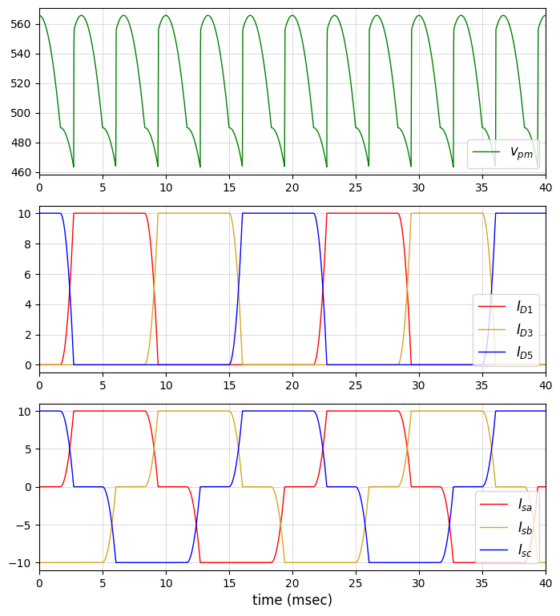

```python
import numpy as np
import matplotlib.pyplot as plt
import gseim_calc as calc
from setsize import set_size

f_hz = 50.0
T = 1.0/f_hz

slv = calc.slv("rectifier_3ph_8.in")

i_slv = 0
i_out = 0
filename = slv.l_filename_all[i_slv][i_out]
print('filename:', filename)
u1 = np.loadtxt(filename)
t1 = u1[:, 0]

v_o = slv.get_array_double(i_slv,i_out,"v_o",u1)
ID1 = slv.get_array_double(i_slv,i_out,"ID1",u1)
ID2 = slv.get_array_double(i_slv,i_out,"ID2",u1)
ID3 = slv.get_array_double(i_slv,i_out,"ID3",u1)
ID4 = slv.get_array_double(i_slv,i_out,"ID4",u1)
ID5 = slv.get_array_double(i_slv,i_out,"ID5",u1)
ID6 = slv.get_array_double(i_slv,i_out,"ID6",u1)
ISa = slv.get_array_double(i_slv,i_out,"ISa",u1)
ISb = slv.get_array_double(i_slv,i_out,"ISb",u1)
ISc = slv.get_array_double(i_slv,i_out,"ISc",u1)

i_out = 1
filename = slv.l_filename_all[i_slv][i_out]
print('filename:', filename)
u2 = np.loadtxt(filename)
t2 = u2[:, 0]

P_IS  = slv.get_array_double(i_slv,i_out,"P_IS",u2)
P_Vsa = slv.get_array_double(i_slv,i_out,"P_Vsa",u2)
P_Vsb = slv.get_array_double(i_slv,i_out,"P_Vsb",u2)
P_Vsc = slv.get_array_double(i_slv,i_out,"P_Vsc",u2)

l_v_o   = calc.avg_rms_3a(t1, v_o  , T, 2.0*T, 1.0e-5*T)
l_P_IS  = calc.avg_rms_3a(t2, P_IS , T, 2.0*T, 1.0e-5*T)
l_P_Vsa = calc.avg_rms_3a(t2, P_Vsa, T, 2.0*T, 1.0e-5*T)
l_ID1   = calc.avg_rms_3a(t1, ID1  , T, 2.0*T, 1.0e-5*T)
l_ISa   = calc.avg_rms_3a(t1, ISa  , T, 2.0*T, 1.0e-5*T)

print('average value of v_pm:'         , "%11.4E"%( l_v_o  [0]))
print('rms value of v_pm:'             , "%11.4E"%( l_v_o  [1]))
print('rms value of ID1:'              , "%11.4E"%( l_ID1  [1]))
print('rms value of ISa:'              , "%11.4E"%( l_ISa  [1]))
print('average power delivered to IS:' , "%11.4E"%(-l_P_IS [0]))
print('average power delivered by Vsa:', "%11.4E"%( l_P_Vsa[0]))

# time instants when the diode current crosses 1.0e-4:
l_cross_1_ID1, l_cross_2_ID1 = calc.cross_over_points_1(t1, ID1, 0.0, T, 1.0e-2)
print('zero-crossing points of D1 current (positive slope):')
for tx in l_cross_1_ID1:
    print("  ", "%11.4E"%tx)
print('zero-crossing points of D1 current (negative slope):')
for tx in l_cross_2_ID1:
    print("  ", "%11.4E"%tx)
theta = (l_cross_2_ID1[0]-l_cross_1_ID1[0])*360.0/T
print('angle of conduction for D1:', "%7.2f"%theta, "degrees")

color1='red'
color2='goldenrod'
color3='blue'
color4='green'
color5='crimson'
color6='cornflowerblue'

fig, ax = plt.subplots(3, sharex=False)
plt.subplots_adjust(wspace=0, hspace=0.0)

set_size(5.5, 6, ax[0])

for i in range(3):
    ax[i].set_xlim(left=0.0, right=2.0*T*1e3)
    ax[i].grid(color='#CCCCCC', linestyle='solid', linewidth=0.5)

#ax[0].tick_params(labelbottom=False)
#ax[1].tick_params(labelbottom=False)
#ax[2].tick_params(labelbottom=False)

ax[0].plot(t1*1e3, v_o, color=color4, linewidth=1.0, label="$v_{pm}$")

ax[1].plot(t1*1e3, ID1, color=color1, linewidth=1.0, label="$I_{D1}$")
ax[1].plot(t1*1e3, ID3, color=color2, linewidth=1.0, label="$I_{D3}$")
ax[1].plot(t1*1e3, ID5, color=color3, linewidth=1.0, label="$I_{D5}$")

ax[2].plot(t1*1e3, ISa, color=color1, linewidth=1.0, label="$I_{sa}$")
ax[2].plot(t1*1e3, ISb, color=color2, linewidth=1.0, label="$I_{sb}$")
ax[2].plot(t1*1e3, ISc, color=color3, linewidth=1.0, label="$I_{sc}$")

ax[2].set_xlabel('time (msec)', fontsize=12)

for i in range(3):
    ax[i].legend(loc = 'lower right',frameon = True, fontsize = 10, title = None,
      markerfirst = True, markerscale = 1.0, labelspacing = 0.5, columnspacing = 2.0,
      prop = {'size' : 12},)

plt.tight_layout()
plt.show()
```

```
filename: rectifier_3ph_8_1.dat
THD in ac line current: 23.74 %
ac line current fundamental: RMS value:   7.7728E+00
```

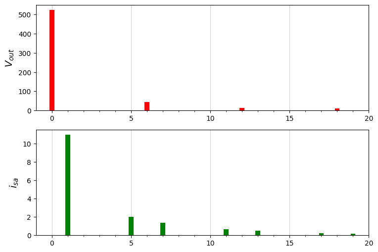

```python
import numpy as np
import matplotlib.pyplot as plt
import gseim_calc as calc
from setsize import set_size

f_hz = 50.0
T = 1.0/f_hz

slv = calc.slv("rectifier_3ph_8.in")

i_slv = 0
i_out = 0
filename = slv.l_filename_all[i_slv][i_out]
print('filename:', filename)
u1 = np.loadtxt(filename)
t1 = u1[:, 0]

v_o = slv.get_array_double(i_slv,i_out,"v_o",u1)
ID1 = slv.get_array_double(i_slv,i_out,"ID1",u1)
ID2 = slv.get_array_double(i_slv,i_out,"ID2",u1)
ID3 = slv.get_array_double(i_slv,i_out,"ID3",u1)
ID4 = slv.get_array_double(i_slv,i_out,"ID4",u1)
ID5 = slv.get_array_double(i_slv,i_out,"ID5",u1)
ID6 = slv.get_array_double(i_slv,i_out,"ID6",u1)
ISa = slv.get_array_double(i_slv,i_out,"ISa",u1)
ISb = slv.get_array_double(i_slv,i_out,"ISb",u1)
ISc = slv.get_array_double(i_slv,i_out,"ISc",u1)

# compute Fourier coeffs:

t_start = T
t_end = 2.0*T

n_fourier = 20

coeff_ISa, thd_ISa = calc.fourier_coeff_1C(t1, ISa,
    t_start, t_end, 1.0e-8, n_fourier)

coeff_v_o, thd_v_o = calc.fourier_coeff_1C(t1, v_o,
    t_start, t_end, 1.0e-8, n_fourier)

print('THD in ac line current:', "%5.2f"%(thd_ISa*100.0), "%")
print("ac line current fundamental: RMS value: ", "%11.4E"%(coeff_ISa[1]/np.sqrt(2.0)))

x = np.linspace(0, n_fourier, n_fourier+1)

y_v_o = np.array(coeff_v_o)
y_ISa = np.array(coeff_ISa)

fig, ax = plt.subplots(2, sharex=False)
plt.subplots_adjust(wspace=0, hspace=0.0)
grid_color='#CCCCCC'

set_size(6, 4, ax[0])

delta = 5.0
x_major_ticks = np.arange(0.0, (float(n_fourier+1)), delta)
x_minor_ticks = np.arange(0.0, (float(n_fourier+1)), 1.0)

for i in range(2):
    ax[i].set_xlim(left=-1.0, right=float(n_fourier))
    ax[i].set_xticks(x_major_ticks)
    ax[i].set_xticks(x_minor_ticks, minor=True)
    ax[i].grid(visible=True, which='major', axis='x', color=grid_color, linestyle='-', zorder=0)

ax[0].set_ylabel('$V_{out}$',fontsize=14)
ax[1].set_ylabel('$i_{sa}$',fontsize=14)

bars1 = ax[0].bar(x, y_v_o, width=0.3, color='red',   label="$v_o$", zorder=3)
bars2 = ax[1].bar(x, y_ISa  , width=0.3, color='green', label="$i_{sa}$" , zorder=3)

plt.tight_layout()
plt.show()
```

This notebook was contributed by **Prof. Nakul Narayanan K**, Govt. Engineering College, Thrissur. He may be contacted at nakul@gectcr.ac.in.